# Coursera Data Science Capstone: SwiftKey Project

Hariharan D

28 October 2017

### 1.Introduction

This course project is part of “Data Science Capstone: SwiftKey Project” - Coursera’s “Data Science” specialization. Goal of this Capstone project is to use “HC Corpora Dataset” to design and develop a prediction algorithm to predict the most likely the successive word in the sequence of words and host the app using Shiny application.

This interim Milestone Report focuses on Exploratory Data Analysis on the corpus of data from various sources relating to Twitter, Blogs and News. This project will focus on the English language datasets. NLP (Natural Language Processing) and R libraries like “tm” and “RWeka” are used to process and tokenize N-grams as first step towards developing prediction model and algorithm.

### 2.Data Source:

Dataset for this project is sourced from this **[website](https://d396qusza40orc.cloudfront.net/dsscapstone/dataset/Coursera-SwiftKey.zip)**

### 3.Set Options and Load R Libraries

Set the chunk options.

```r
library(knitr)

knitr::opts_chunk$set(echo = TRUE, tidy = TRUE, warning = FALSE, message = FALSE, fig.align = "center", cache = TRUE)
```

Load the necessary libraries.

Note: It is assumed that the below libraries are aready installed.

```r
library(downloader)
library(plyr)
library(dplyr)
library(tm)
library(ggplot2)
library(RWeka)
library(SnowballC)
library(wordcloud)
```

### 4.Load Dataset and Clean the Data

Loading the dataset.

```r
set.seed(12345)

setwd("C:/Users/Welcome/Desktop/Data Science/R/Coursera Reading Material/Course 10 - Data Science Capstone/Project/")

fileUrl <- "https://d396qusza40orc.cloudfront.net/dsscapstone/dataset/Coursera-SwiftKey.zip"

if (!file.exists("./DataSet")) {
    dir.create("./DataSet")
}

if (!file.exists("./DataSet/Coursera-SwiftKey.zip")) {
    download.file(fileUrl, destfile = "./DataSet/Coursera-SwiftKey.zip", mode = "wb")
    Download_Date <- Sys.time()
}

if (!file.exists("./DataSet/final")) {
    unzip(zipfile = "./DataSet/Coursera-SwiftKey.zip", exdir = "./DataSet")
}

pathFiles <- file.path("./DataSet/final", "en_US")
files <- list.files(pathFiles, recursive = TRUE)
files
```

```
## [1] "en_US.blogs.txt"   "en_US.news.txt"    "en_US.twitter.txt"
```

```r
enUSTwitter <- "./DataSet/final/en_US/en_US.twitter.txt"
enUSBlogs <- "./DataSet/final/en_US/en_US.blogs.txt"
enUSNews <- "./DataSet/final/en_US/en_US.news.txt"
```

### 5.Summary Statistics of Dataset

Summary Statistics for Tweets, Blogs, News are provided for the below parameters;

- File Size (in MB)
- Total number of Lines
- Total number of Words
- Average number of Words per Line
- Maximum Characters per Line

```r
con <- file(enUSTwitter, "r")
lineTwitter <- readLines(con, encoding = "UTF-8", skipNul = TRUE)
close(con)

con <- file(enUSBlogs, "r")
lineBlogs <- readLines(con, encoding = "UTF-8", skipNul = TRUE)
close(con)

con <- file(enUSNews, "r")
lineNews <- readLines(con, encoding = "UTF-8", skipNul = TRUE)
close(con)


fileSizeMB <- function(lns) {
    file.info(lns)$size/(1024^2)
}

lineCount <- function(lns) {
    length(lns)
}

wordCount <- function(lns) {
    sum(sapply(gregexpr("\\S+", lns), length))
}

meanSentenceLength <- function(lns) {
    mean(sapply(gregexpr("\\S+", lns), length))
}

maxChars <- function(lns) {
    max(nchar(lns))
}

countTwitter <- c(round(fileSizeMB(enUSTwitter), 0), lineCount(lineTwitter),
    wordCount(lineTwitter), meanSentenceLength(lineTwitter), maxChars(lineTwitter))
countBlogs <- c(round(fileSizeMB(enUSBlogs), 0), lineCount(lineBlogs), wordCount(lineBlogs),
    meanSentenceLength(lineBlogs), maxChars(lineBlogs))
countNews <- c(round(fileSizeMB(enUSNews), 0), lineCount(lineNews), wordCount(lineNews),
    meanSentenceLength(lineNews), maxChars(lineNews))

countEnUS <- rbind(countTwitter, countBlogs, countNews)
rownames(countEnUS) <- c("Twitter", "Blogs", "News")
colnames(countEnUS) <- c("File-Size(MB)", "Lines-Count", "Words-Count", "Mean-Words-Per-Line",
    "Max-Chars-Per-Line")

countEnUS
```

```
##         File-Size(MB) Lines-Count Words-Count Mean-Words-Per-Line
## Twitter           159     2360148    30373583            12.86936
## Blogs             200      899288    37334131            41.51521
## News              196       77259     2643969            34.22215
##         Max-Chars-Per-Line
## Twitter                140
## Blogs                40833
## News                  5760
```

### 6.Sampling of Dataset

First step, is to convert the encoding of the dataset to “ASCII” format. Once the dataset is encoded then sampling is performed to extract 2% of source data.

```r
lineTwitter <- iconv(lineTwitter, "UTF-8", "ASCII", sub = "")
lineBlogs <- iconv(lineBlogs, "UTF-8", "ASCII", sub = "")
lineNews <- iconv(lineNews, "UTF-8", "ASCII", sub = "")

set.seed(123456)

sampleData <- c(sample(lineTwitter, length(lineTwitter) * 0.02), sample(lineBlogs,
    length(lineBlogs) * 0.02), sample(lineNews, length(lineNews) * 0.02))
sampleData <- unlist(strsplit(sampleData, "[\\.\\,!\\?\\:]+"))
```

### 7.Tokenize and Clean Dataset

Tokenization is performed by splitting each line into sentences. Then dataset is cleansed to remove the following; non-word characters, lower-case, punctuations, whitespaces.

```r
corpusData <- sampleData
corpusData <- gsub("(f|ht)tp(s?)://(.*)[.][a-z]+", " ", corpusData)
corpusData <- gsub("@[^\\s]+", " ", corpusData)
corpusData <- tolower(corpusData)
# corpusData <- removeWords(corpusData, stopwords('english'))
corpusData <- removePunctuation(corpusData)
corpusData <- removeNumbers(corpusData)
corpusData <- trimws(corpusData)
corpusDataCloud <- unlist(strsplit(corpusData, "\\s"))
corpusData <- strsplit(corpusData, "\\s")
```

### 8.Create Word Cloud

Word Cloud is generated on the dataset.

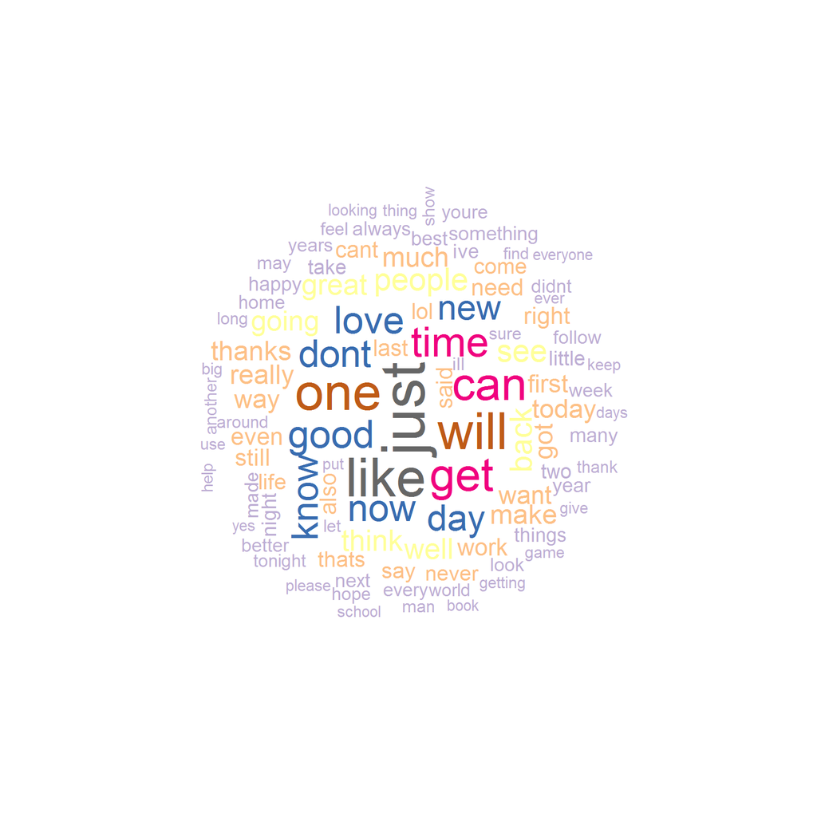

```r
wordcloud(corpusDataCloud, max.words = 100, random.order = FALSE, colors = brewer.pal(8,
    "Accent"))
```

### 9.Remove Profanity words

Profanity words are removed from the corpus data.

```r
profanityFilter <- function(termList) {
    profanities <- readLines("./Profanity.txt", skipNul = TRUE)
    lapply(termList, setdiff, y = profanities)
}

corpusData <- profanityFilter(corpusData)

head(corpusData, 5)
```

```
## [[1]]
##  [1] "why"    "do"     "native" "apps"   "get"    "more"   "usage"
##  [8] "than"   "mobile" "web"
##
## [[2]]
## [1] "sa"     "is"     "lovely"
##
## [[3]]
## [1] "but"      "you"      "the"      "one"      "not"      "replying"
##
## [[4]]
## [1] "what" "did"  "i"    "do"
##
## [[5]]
## [1] "i"             "feel"          "your"          "acevesinduced"
## [5] "pain"
```

```r
length(corpusData)
```

```
## [1] 200356
```

```r
sum(sapply(corpusData, length))
```

```
## [1] 1320773
```

### 10.Term Frequencies

Term frequencies are identified for the most common words in the dataset and a frequency table is created.

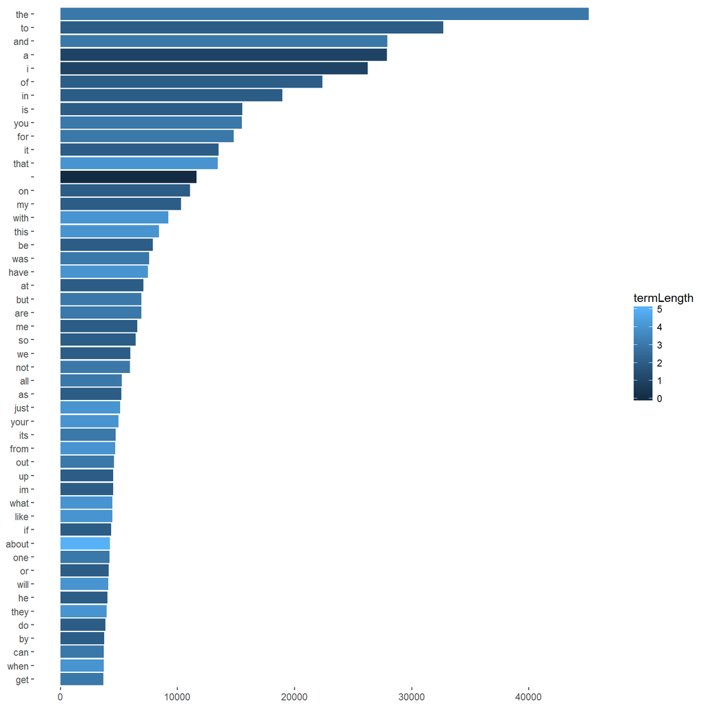

```r
getFreq <- function(termList) {
    term <- data.frame(unlist(termList))
    grouped <- as.data.frame(table(term))
    freq <- grouped[order(-grouped$Freq), ]
    rownames(freq) <- 1:nrow(freq)

    total <- sum(freq$Freq)
    freq$CumFreq <- cumsum(freq$Freq)
    freq$Coverage <- freq$CumFreq/total

    return(freq)
}

sampleENTermFrequency <- getFreq(corpusData)

tmp <- sampleENTermFrequency[1:50, ]
tmp$termLength <- nchar(as.character(tmp$term))

ggplot(tmp, aes(x = reorder(term, Freq), y = Freq, fill = termLength)) + geom_bar(stat = "identity") +
    coord_flip() + theme(panel.border = element_blank(), panel.grid.major = element_blank(),
    panel.grid.minor = element_blank(), panel.background = element_blank(),
    axis.title.y = element_blank(), axis.title.x = element_blank())
```

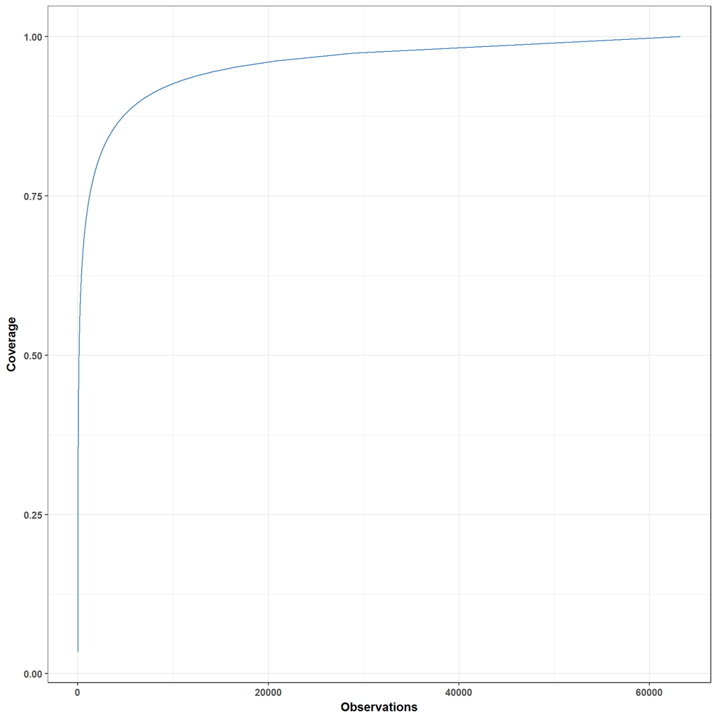

```r
filterFrequencyTable <- function(freqTable, binCoverageShift = 0.01) {
    shiftTotal <- 0

    freqTable$keep <- FALSE

    for (n in 1:nrow(freqTable)) {
        shiftTotal <- shiftTotal + freqTable$Coverage[n]

        if (shiftTotal >= binCoverageShift) {
            freqTable$keep[n] <- TRUE
            shiftTotal <- 0
        }
    }

    freqTable[freqTable$keep == TRUE, ]
}


tmpFilter <- filterFrequencyTable(sampleENTermFrequency, 0.005)

ggplot(tmpFilter, aes(y = as.integer(rownames(tmpFilter)), x = Coverage)) +
    geom_line(color = "steelblue") + coord_flip() + labs(x = "Coverage", y = "Observations") +
    theme_bw() + theme(plot.title = element_text(hjust = 0.5, face = "bold"),
    axis.text = element_text(face = "bold"), axis.title = element_text(face = "bold"))
```

### 11.Create N-grams

Dataset is converted to N-grams format for NLP.

```r
createNgram <- function(vec, n = 2) {
    l <- length(vec)
    if (l < n) {
        return(c())
    } else if (l == n) {
        return(paste(vec, collapse = " "))
    } else {
        numNgrams <- l - n + 1
        mtrx <- matrix(nrow = numNgrams, ncol = n)
        for (i in 1:n) {
            m <- l - n + i
            mtrx[, i] <- vec[i:m]
        }
        ngrams <- apply(mtrx, 1, paste, collapse = " ")
        return(ngrams)
    }
}

transformNGram <- function(termList, n = 2) {
    lapply(termList, createNgram, n = n)
}
```

### 12.Create Uni-grams

Uni-gram frequency table is created for the corpus.

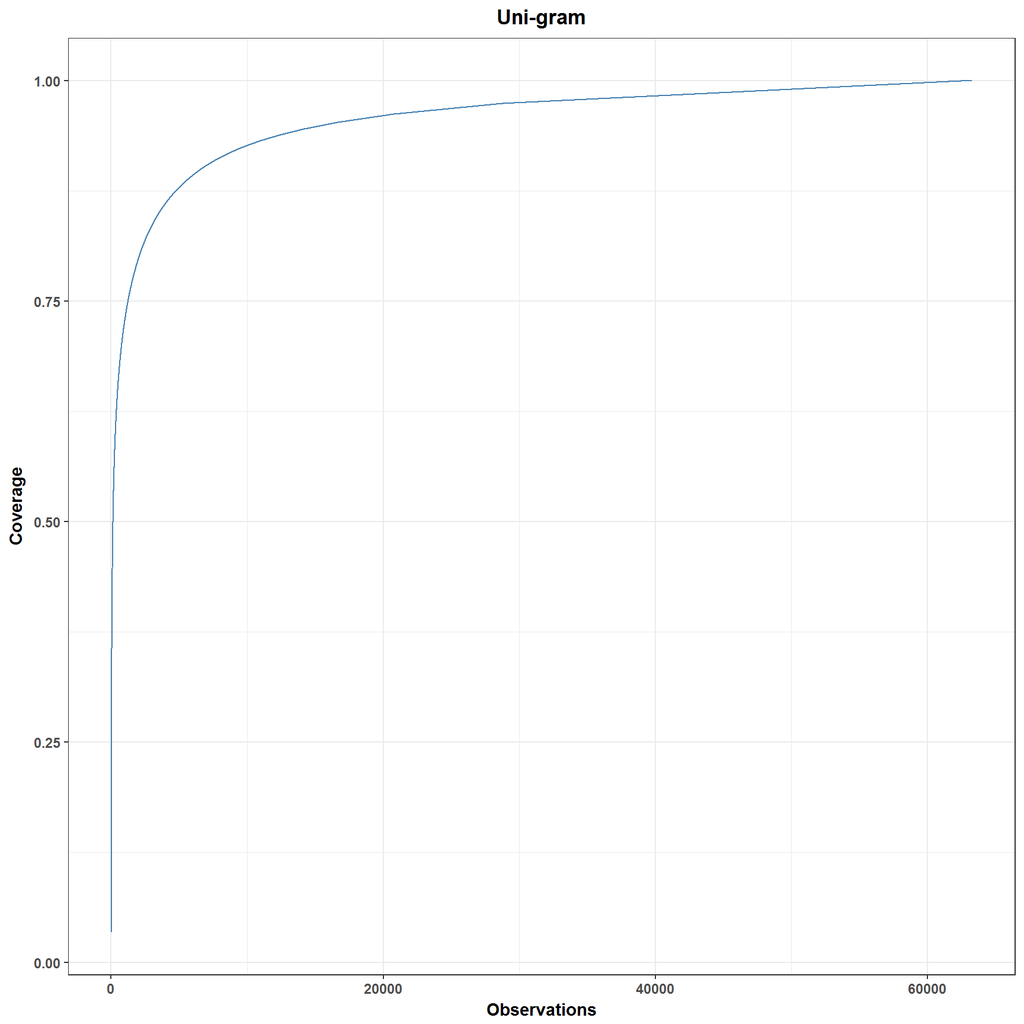

```r
sampleENUniGram <- transformNGram(corpusData, 1)
sampleENUniGramFrequency <- getFreq(sampleENUniGram)

plotUniGram <- filterFrequencyTable(sampleENUniGramFrequency, 0.005)
ggplot(plotUniGram, aes(y = as.integer(rownames(plotUniGram)), x = Coverage)) +
    geom_line(color = "steelblue") + coord_flip() + labs(title = "Uni-gram",
    x = "Coverage", y = "Observations") + theme_bw() + theme(plot.title = element_text(hjust = 0.5,
    face = "bold"), axis.text = element_text(face = "bold"), axis.title = element_text(face = "bold"))
```

### 13.Create Bi-grams

Bi-gram frequency table is created for the corpus.

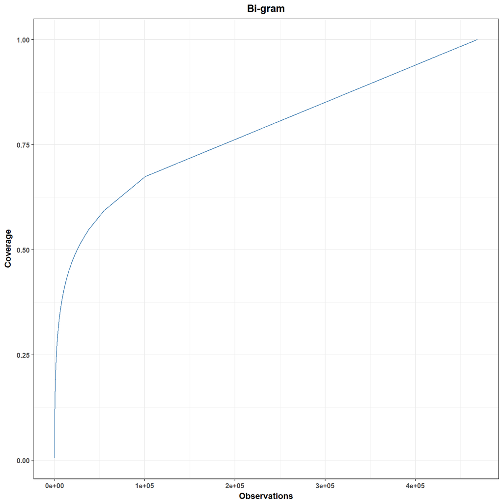

```r
sampleENBiGrams <- transformNGram(corpusData, 2)
sampleENBiGramsFrequency <- getFreq(sampleENBiGrams)

plotBiGram <- filterFrequencyTable(sampleENBiGramsFrequency, 0.005)
ggplot(plotBiGram, aes(y = as.integer(rownames(plotBiGram)), x = Coverage)) +
    geom_line(color = "steelblue") + coord_flip() + labs(title = "Bi-gram",
    x = "Coverage", y = "Observations") + theme_bw() + theme(plot.title = element_text(hjust = 0.5,
    face = "bold"), axis.text = element_text(face = "bold"), axis.title = element_text(face = "bold"))
```

### 13.Create Tri-grams

Tri-gram frequency table is created for the corpus.

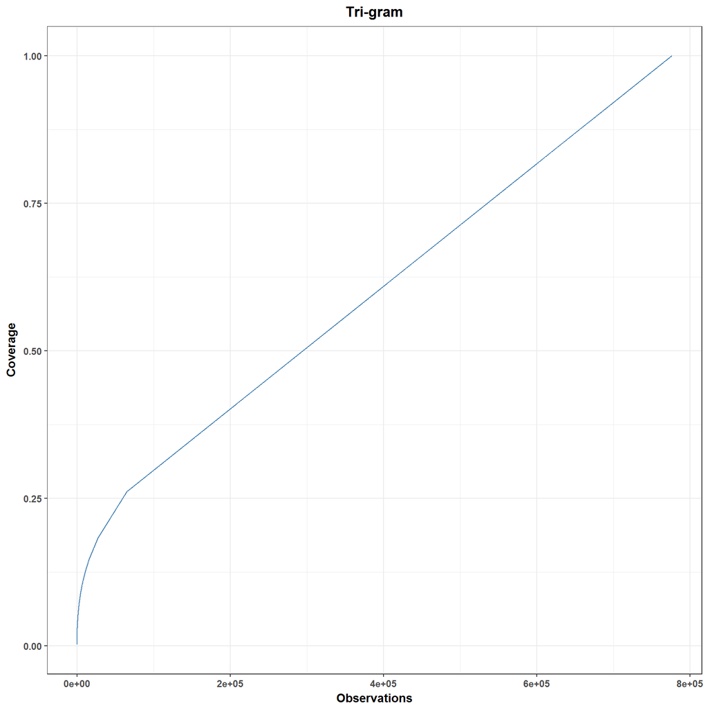

```r
sampleENTriGrams <- transformNGram(corpusData, 3)
sampleENTriGramsFrequency <- getFreq(sampleENTriGrams)

plotTriGram <- filterFrequencyTable(sampleENTriGramsFrequency, 0.005)
ggplot(plotTriGram, aes(y = as.integer(rownames(plotTriGram)), x = Coverage)) +
    geom_line(color = "steelblue") + coord_flip() + labs(title = "Tri-gram",
    x = "Coverage", y = "Observations") + theme_bw() + theme(plot.title = element_text(hjust = 0.5,
    face = "bold"), axis.text = element_text(face = "bold"), axis.title = element_text(face = "bold"))
```

### 14.Coverage Factor

Coverage factor for Uni-gram, Bi-grams, Tri-grams are computed.

```r
coverageFactor <- function(freqTable, coverage) {
    pos <- nrow(freqTable[freqTable$Coverage < coverage, ])
    pos/nrow(freqTable)
}

coverageFactorValues <- c(0.1, 0.5, 0.9)
uniCov <- sapply(coverageFactorValues, coverageFactor, freqTable = sampleENUniGramFrequency)
biCov <- sapply(coverageFactorValues, coverageFactor, freqTable = sampleENBiGramsFrequency)
triCov <- sapply(coverageFactorValues, coverageFactor, freqTable = sampleENTriGramsFrequency)

infoCoverage <- rbind(uniCov, biCov, triCov)
rownames(infoCoverage) <- c("Uni-gram", "Bi-gram", "Tri-gram")
colnames(infoCoverage) <- coverageFactorValues
infoCoverage
```

```
##                   0.1         0.5       0.9
## Uni-gram 4.740909e-05 0.002070197 0.1050269
## Bi-gram  4.416999e-04 0.053435017 0.7589556
## Tri-gram 8.343923e-03 0.380313441 0.8760617
```

### 15.Summary & Plans for Shiny app

- Stored N-gram frequencies of the corpus source is used to predicting the successive word in a sequence of words.
- Higher degree of N-grams will have lower frequency than that of lower degree N-grams.
- Next step of this capstone project would be to tune and precision the predictive algorithm model, and deploy the same using Shiny app.
- Shiny app’s UI will have a text box for user input. When the user enters a word or phrase the app will use the predictive algorithm to suggest the most likely sucessive word.